# Global Analysis of Education and Occupation

##### By Tyler Gorecki, Ricky Kuehn, Doruk Ozar, Luke Schneider, James Siegener

### Import, Cleaning

*Libraries*

```r
library(tidyverse)
```

```r
library(ggcorrplot)
library(grid)
library(vcd)
library(glmnet)
library(caret)
library(pls)
library(PRROC)
library(pROC)
```

*Load data*

```r
df = expectancy = read.csv('~/Downloads/linear_models_project_data.csv')
head(df)
```

```
##   X age        workclass fnlwgt education education.num     marital.status
## 1 0  39        State-gov  77516 Bachelors            13      Never-married
## 2 1  50 Self-emp-not-inc  83311 Bachelors            13 Married-civ-spouse
## 3 2  38          Private 215646   HS-grad             9           Divorced
## 4 3  53          Private 234721      11th             7 Married-civ-spouse
## 5 4  28          Private 338409 Bachelors            13 Married-civ-spouse
## 6 5  37          Private 284582   Masters            14 Married-civ-spouse
##          occupation  relationship  race    sex capital.gain capital.loss
## 1      Adm-clerical Not-in-family White   Male         2174            0
## 2   Exec-managerial       Husband White   Male            0            0
## 3 Handlers-cleaners Not-in-family White   Male            0            0
## 4 Handlers-cleaners       Husband Black   Male            0            0
## 5    Prof-specialty          Wife Black Female            0            0
## 6   Exec-managerial          Wife White Female            0            0
##   hours.per.week native.country income
## 1             40  United-States  <=50K
## 2             13  United-States  <=50K
## 3             40  United-States  <=50K
## 4             40  United-States  <=50K
## 5             40           Cuba  <=50K
## 6             40  United-States  <=50K
```

*Drop missing values*

```r
df = replace(df, df=="NaN", NA)
df = df %>% drop_na()
df %>% head()
```

```
##   X age        workclass fnlwgt education education.num     marital.status
## 1 0  39        State-gov  77516 Bachelors            13      Never-married
## 2 1  50 Self-emp-not-inc  83311 Bachelors            13 Married-civ-spouse
## 3 2  38          Private 215646   HS-grad             9           Divorced
## 4 3  53          Private 234721      11th             7 Married-civ-spouse
## 5 4  28          Private 338409 Bachelors            13 Married-civ-spouse
## 6 5  37          Private 284582   Masters            14 Married-civ-spouse
##          occupation  relationship  race    sex capital.gain capital.loss
## 1      Adm-clerical Not-in-family White   Male         2174            0
## 2   Exec-managerial       Husband White   Male            0            0
## 3 Handlers-cleaners Not-in-family White   Male            0            0
## 4 Handlers-cleaners       Husband Black   Male            0            0
## 5    Prof-specialty          Wife Black Female            0            0
## 6   Exec-managerial          Wife White Female            0            0
##   hours.per.week native.country income
## 1             40  United-States  <=50K
## 2             13  United-States  <=50K
## 3             40  United-States  <=50K
## 4             40  United-States  <=50K
## 5             40           Cuba  <=50K
## 6             40  United-States  <=50K
```

*Rename ‘income’ values*

```r
df = replace(df, df=="<=50K.", "<=50K")
df = replace(df, df==">50K.", ">50K")

df %>% head()
```

```
##   X age        workclass fnlwgt education education.num     marital.status
## 1 0  39        State-gov  77516 Bachelors            13      Never-married
## 2 1  50 Self-emp-not-inc  83311 Bachelors            13 Married-civ-spouse
## 3 2  38          Private 215646   HS-grad             9           Divorced
## 4 3  53          Private 234721      11th             7 Married-civ-spouse
## 5 4  28          Private 338409 Bachelors            13 Married-civ-spouse
## 6 5  37          Private 284582   Masters            14 Married-civ-spouse
##          occupation  relationship  race    sex capital.gain capital.loss
## 1      Adm-clerical Not-in-family White   Male         2174            0
## 2   Exec-managerial       Husband White   Male            0            0
## 3 Handlers-cleaners Not-in-family White   Male            0            0
## 4 Handlers-cleaners       Husband Black   Male            0            0
## 5    Prof-specialty          Wife Black Female            0            0
## 6   Exec-managerial          Wife White Female            0            0
##   hours.per.week native.country income
## 1             40  United-States  <=50K
## 2             13  United-States  <=50K
## 3             40  United-States  <=50K
## 4             40  United-States  <=50K
## 5             40           Cuba  <=50K
## 6             40  United-States  <=50K
```

*Collapse education into bins*

```r
df$education = replace(df$education, df$education=="1st-4th", "Elementary/Middle")
df$education = replace(df$education, df$education=="5th-6th", "Elementary/Middle")
df$education = replace(df$education, df$education=="7th-8th", "Elementary/Middle")
df$education = replace(df$education, df$education=="Preschool", "Elementary/Middle")
df$education = replace(df$education, df$education=="Assoc-acdm", "Associates")
df$education = replace(df$education, df$education=="Assoc-voc", "Associates")
df$education = replace(df$education, df$education=="9th", "Highschool")
df$education = replace(df$education, df$education=="10th", "Highschool")
df$education = replace(df$education, df$education=="11th", "Highschool")
df$education = replace(df$education, df$education=="12th", "Highschool")
df$education = replace(df$education, df$education=="HS-grad", "Highschool")

head(df)
```

```
##   X age        workclass fnlwgt  education education.num     marital.status
## 1 0  39        State-gov  77516  Bachelors            13      Never-married
## 2 1  50 Self-emp-not-inc  83311  Bachelors            13 Married-civ-spouse
## 3 2  38          Private 215646 Highschool             9           Divorced
## 4 3  53          Private 234721 Highschool             7 Married-civ-spouse
## 5 4  28          Private 338409  Bachelors            13 Married-civ-spouse
## 6 5  37          Private 284582    Masters            14 Married-civ-spouse
##          occupation  relationship  race    sex capital.gain capital.loss
## 1      Adm-clerical Not-in-family White   Male         2174            0
## 2   Exec-managerial       Husband White   Male            0            0
## 3 Handlers-cleaners Not-in-family White   Male            0            0
## 4 Handlers-cleaners       Husband Black   Male            0            0
## 5    Prof-specialty          Wife Black Female            0            0
## 6   Exec-managerial          Wife White Female            0            0
##   hours.per.week native.country income
## 1             40  United-States  <=50K
## 2             13  United-States  <=50K
## 3             40  United-States  <=50K
## 4             40  United-States  <=50K
## 5             40           Cuba  <=50K
## 6             40  United-States  <=50K
```

### EDA and Research Questions

*How does the distribution of income vary across different age groups?*

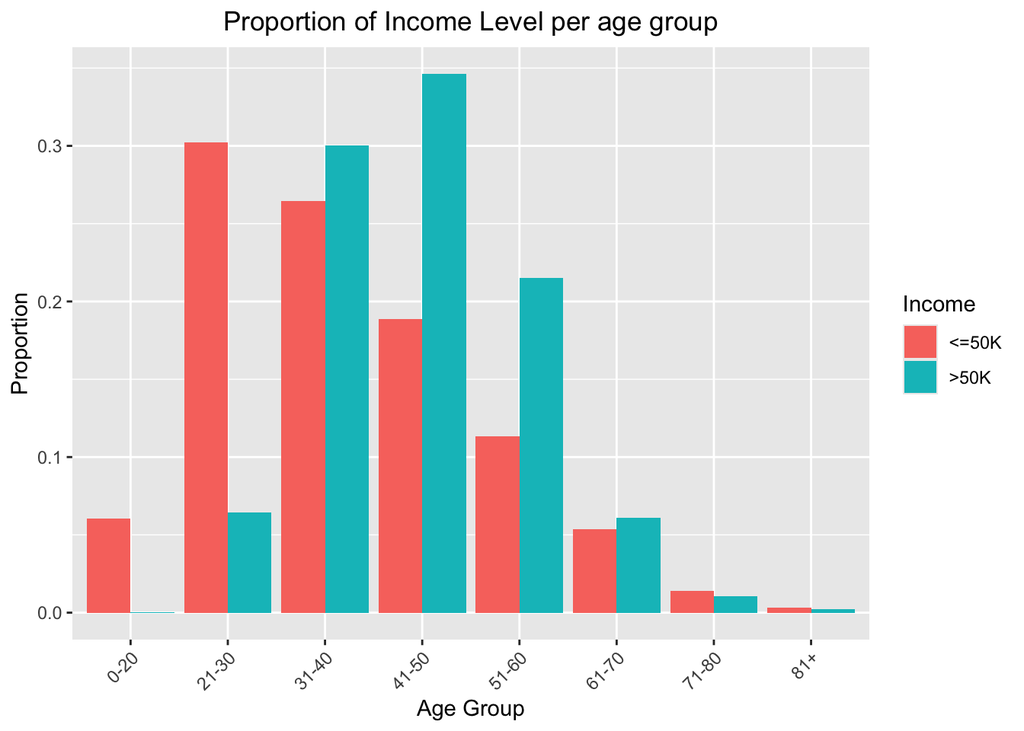

```r
df$age_group <- cut(df$age,
                      breaks = c(0, 20, 30, 40, 50, 60, 70, 80, Inf),
                      labels = c("0-20", "21-30", "31-40", "41-50", "51-60", "61-70", "71-80", "81+"),
                      right = FALSE)

df %>%
  group_by(income, age_group) %>%
  summarise(count = n()) %>%
  mutate(proportion = count / sum(count)) %>%
  ungroup() %>%
  ggplot(aes(x = age_group, y = proportion, fill = income)) +
  geom_bar(stat = 'identity', position = 'dodge')+theme(axis.text.x = element_text(angle = 45, hjust = 1)) + ggtitle("Proportion of Income Level per age group") + xlab("Age Group") + ylab("Proportion") + theme(plot.title = element_text(hjust = 0.5)) +
  labs(fill = "Income")
```

*What is the relationship between the number of hours worked per week and income level?*

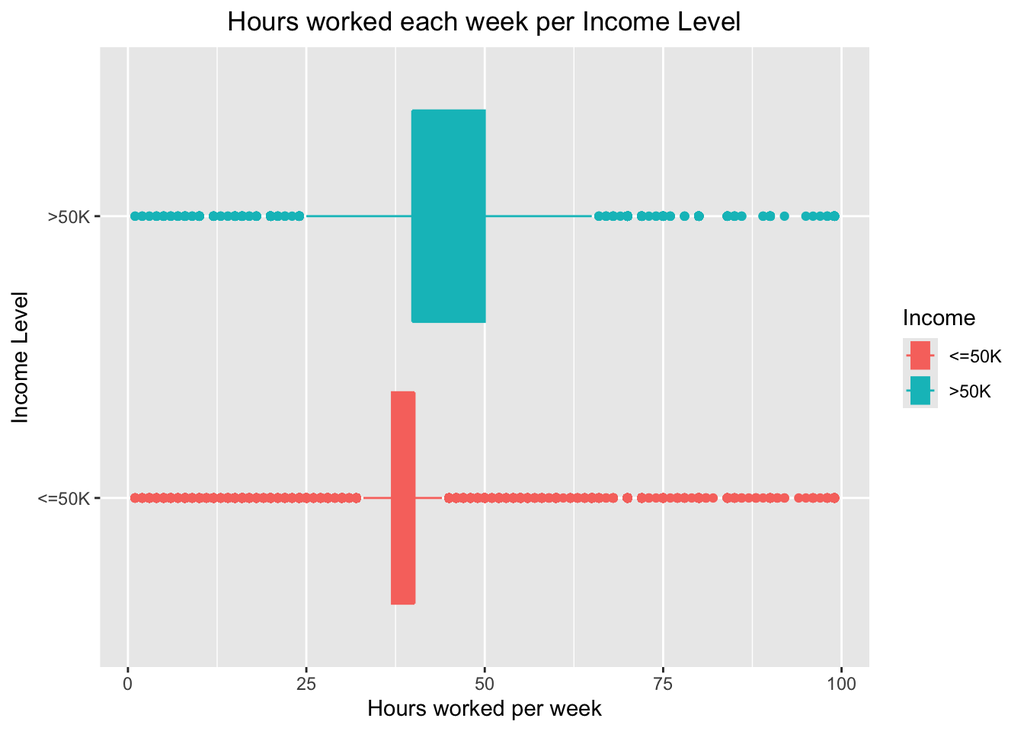

```r
df2 <- df
names(df2)[names(df2) == 'income'] <- 'Income'
df2 %>% ggplot(aes(x=hours.per.week, y=Income, color=Income, fill=Income))+geom_boxplot() + ggtitle("Hours worked each week per Income Level") + xlab("Hours worked per week") + ylab("Income Level") + theme(plot.title = element_text(hjust = 0.5))
```

*What is the relationship between the number of hours worked per week and income level?*

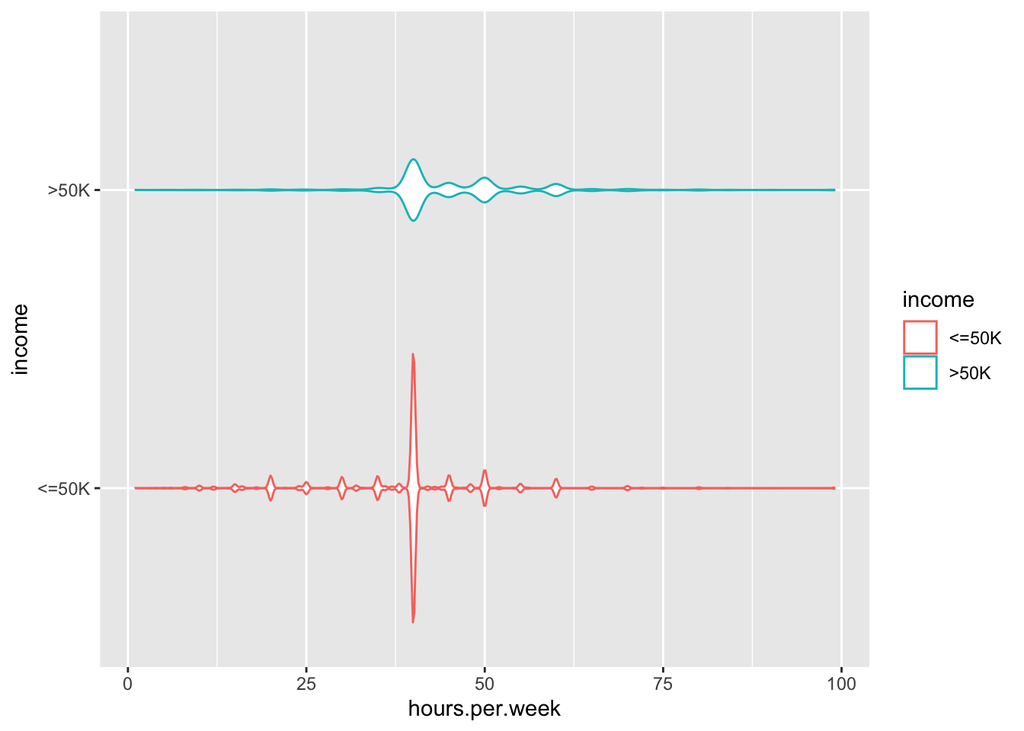

```r
df %>% ggplot(aes(x=hours.per.week, y=income, color=income))+geom_violin()
```

*Converting income column to dummy variables, find correlation between education number and income greater than 50K*

```r
data_dummies = fastDummies::dummy_cols(df, select_columns="income")
cor(data_dummies$education.num, data_dummies$`income_>50K`)
```

```
## [1] 0.3327999
```

*Income level depending on education level*

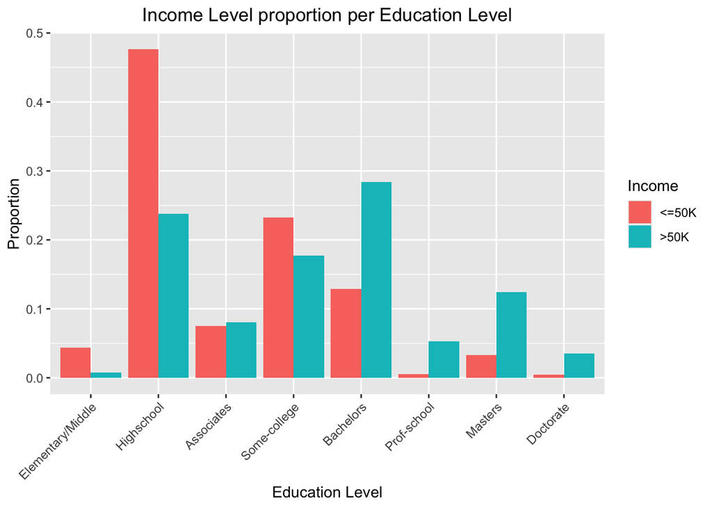

```r
df$education = factor(df$education, levels = c("Elementary/Middle", "Highschool", 'Associates', "Some-college", 'Bachelors','Prof-school', 'Masters', 'Doctorate'))

df %>%
  group_by(income, education) %>%
  summarise(count = n()) %>%
  mutate(proportion = count / sum(count)) %>%
  ungroup() %>%
  ggplot(aes(x = education, y = proportion, fill = income)) +
  geom_bar(stat = 'identity', position = 'dodge')+theme(axis.text.x = element_text(angle = 45, hjust = 1)) + ggtitle("Income Level proportion per Education Level") + xlab("Education Level") + ylab("Proportion") + theme(plot.title = element_text(hjust = 0.5)) +
  labs(fill = "Income")
```

Interpretation: As we can see from the above graph, the most amount of people who earns greater than 50K is people who have bachelors degree and this is because in our data we have more people who have bachelors degree than people who have Masters or Doctorate degree. Same idea applies to Highschool column, because we have more data on people whose highest level of education is highschool, that is why it looks people who earns less than 50K is in highschool column

*Income level depending on occupation*

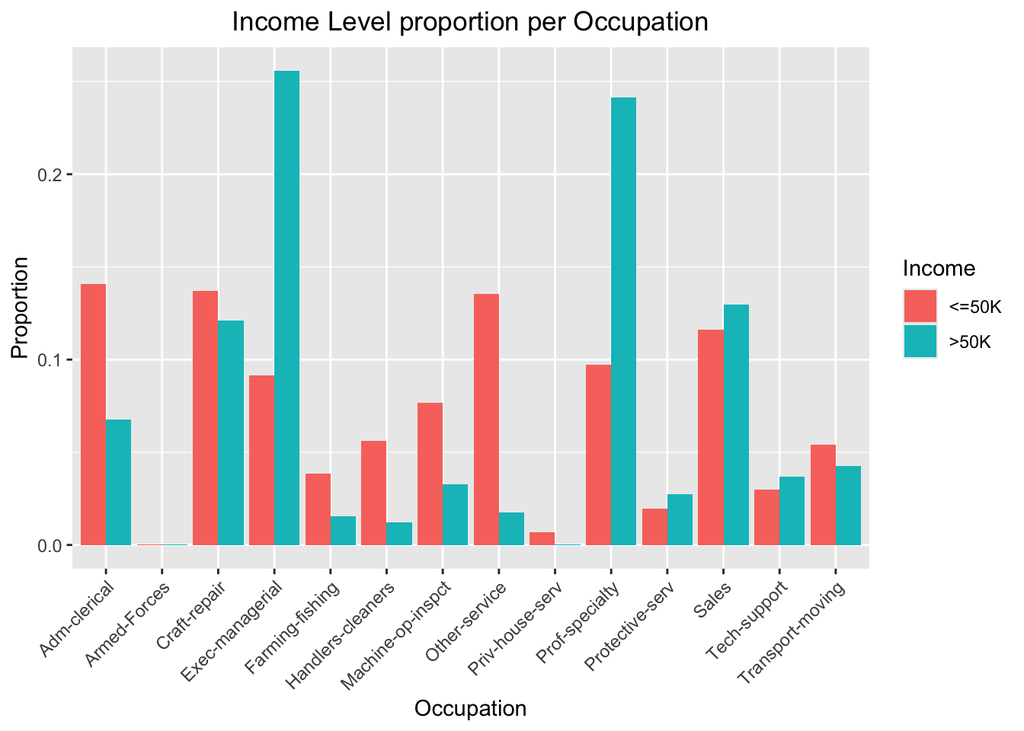

```r
df %>%
  group_by(income, occupation) %>%
  summarise(count = n()) %>%
  mutate(proportion = count / sum(count)) %>%
  ungroup() %>%
  ggplot(aes(x = occupation, y = proportion, fill = income)) +
  geom_bar(stat = 'identity', position = 'dodge')+theme(axis.text.x = element_text(angle = 45, hjust = 1)) + ggtitle("Income Level proportion per Occupation") + xlab("Occupation") + ylab("Proportion") + theme(plot.title = element_text(hjust = 0.5)) +
  labs(fill = "Income")
```

Interpretation: As we can see from the bar graph above, we can say that the most amount of people who earns above 50K is people who has executive/managerial positions. After that it comes people who has a position in Prof/specialty. These makes sense because in real life as well, Executive managers earn a lot of money and Professors who make a lot of research can earn a lot of money. On the other hand, the most amount of people who make less than 50K is people who work in clerical jobs. These might include data entring, answering phone calls, filling paperwork and etc.

*Correlation Matrix between all the numerical variables.*

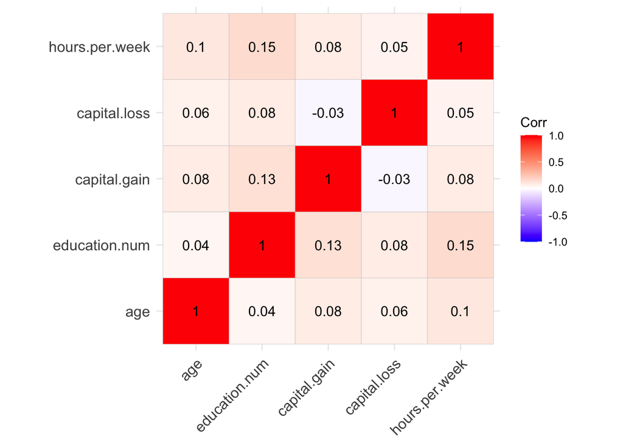

```r
cor_mat <- cor(df[,c('age',"education.num", 'capital.gain','capital.loss','hours.per.week')])
ggcorrplot(cor_mat,lab=TRUE, type='full')
```

Interpretation: As you can see in the correlation matrix, multicollinearity is not an issue becase there are no variables that are highly correlated with each other

*What is the relationship between mean hours.per.week and age?*

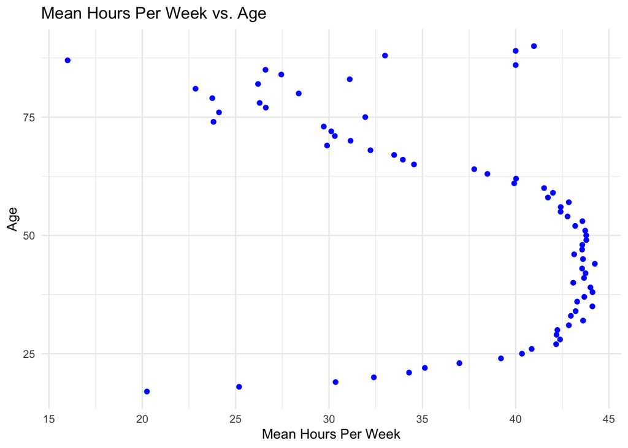

```r
mean_df <- df %>%
  group_by(age) %>%
  summarise(mean_hours_per_week = mean(hours.per.week))

ggplot(mean_df, aes(x = mean_hours_per_week, y = age)) +
  geom_point(color = "blue") +
  labs(title = "Mean Hours Per Week vs. Age",
       x = "Mean Hours Per Week",
       y = "Age") +
  theme_minimal()
```

*What is the relationship between marital status and age?*

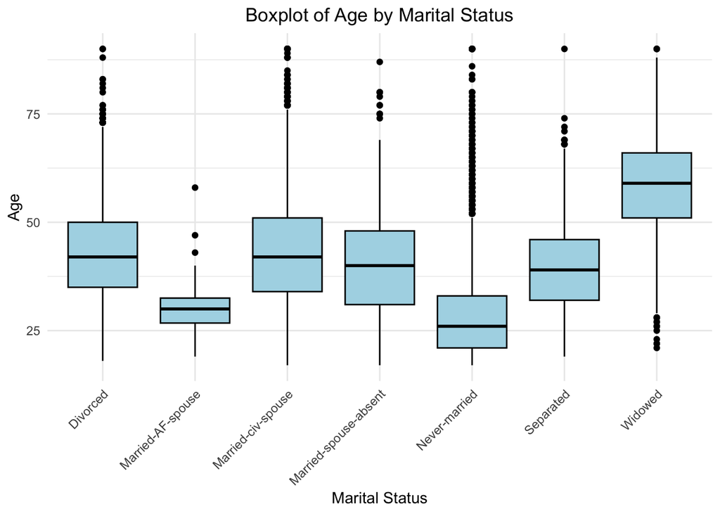

```r
ggplot(df, aes(x = marital.status, y = age)) +
  geom_boxplot(fill = "lightblue", color = "black") +
  labs(title = "Boxplot of Age by Marital Status",
       x = "Marital Status",
       y = "Age") +
  theme_minimal() +
  theme(axis.text.x = element_text(angle = 45, hjust = 1), plot.title = element_text(hjust = 0.5))
```

*Examine distribution of capital loss and capital gain*

```r
value_counts <- table(df$capital.loss)
df_capital.loss_count <- data.frame(value_counts)
df_capital.loss_count$pct <- round(100*df_capital.loss_count$Freq / sum(df_capital.loss_count$Freq),2)
head(df_capital.loss_count)
```

```
##   Var1  Freq   pct
## 1    0 43082 95.27
## 2  155     1  0.00
## 3  213     5  0.01
## 4  323     5  0.01
## 5  419     1  0.00
## 6  625    17  0.04
```

```r
value_counts2 <- table(df$capital.gain)
df_capital.gain_count <- data.frame(value_counts2)
df_capital.gain_count$pct <- round(100*df_capital.gain_count$Freq / sum(df_capital.gain_count$Freq),2)
head(df_capital.gain_count)
```

```
##   Var1  Freq   pct
## 1    0 41432 91.62
## 2  114     8  0.02
## 3  401     2  0.00
## 4  594    42  0.09
## 5  914    10  0.02
## 6  991     4  0.01
```

Interpretation: As we can see from the above tables, most of the people in the dataset has 0 capital loss and capital gain. This is because in real life, most of the people do not have capital loss or gain.

*Association between education level and income*

```r
contingency_table = table(df$education, df$income)
chisq.test(contingency_table)
```

```
##
##  Pearson's Chi-squared test
##
## data:  contingency_table
## X-squared = 5814.2, df = 7, p-value < 2.2e-16
```

Interpretation: As we can see from the Chi-squared test, education and income has a very high association because the chi-square value is extremely high and p value is really low. This means that we have to reject null hypothesis and conclude that there is a high association between education and income.

### Logistic Regression with Lasso and Cross Validation

*Train Test split by 80% training and 20% testing datasets*

```r
X = model.matrix(income~0+., data=df)
X = scale(X)
y= df$income

train_index = sample(1:nrow(df), 0.8 * nrow(df))

train_X = X[train_index, ]
train_y = y[train_index]

test_X = X[-train_index, ]
test_y = y[-train_index]
```

*10 fold cross validation and finding best lambda for ‘income’ categorical variable*

```r
set.seed(123)
cv_model = cv.glmnet(x=train_X, y=train_y, alpha=1, family="binomial", type.measure = "class", nfolds = 10)

best_lambda <- cv_model$lambda.min
best_lambda
```

```
## [1] 0.0001231319
```

*Plot cross validation model*

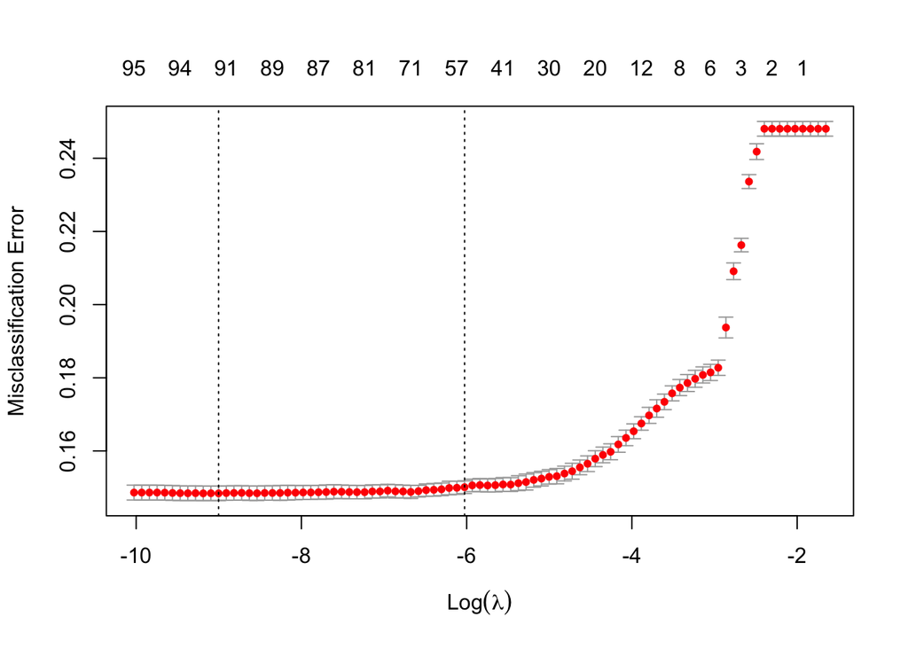

```r
plot(cv_model)
```

*Store names of predictor variables*

```r
coefficient_matrix = as.matrix(coef(cv_model))

non_zero_indices <- which(coefficient_matrix != 0)
non_zero_coefs <- coefficient_matrix[non_zero_indices, ]

names_of_predictors = rownames(coefficient_matrix)[non_zero_indices]
#cbind(rownames(coefficient_matrix)[non_zero_indices], coefficient_matrix[coefficient_matrix!=0])
```

*Finalize logistic model using the ideal lambda value*

```r
final_model <- glmnet(train_X, train_y, alpha = 1, family = "binomial", lambda = best_lambda)
```

*Cast test_y data as 1s and 0s*

```r
#cbind(predicted_classes, test_y)
test_y = ifelse(test_y == ">50K", 1, 0)
```

*Make predictions, construct confusion matrix where 0 represents individuals who earn <= 50K and 1 represents individuals who earn > 50K*

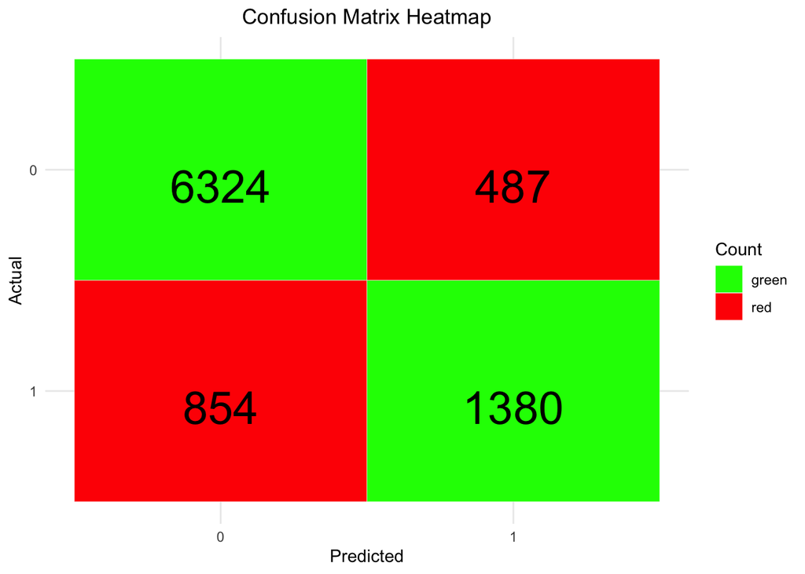

```r
predictions <- predict(final_model, newx = test_X, type = "response")
#predicted_classes <- ifelse(predictions > 0.5, ">50K", "<=50K")
predicted_classes <- ifelse(predictions > 0.5, 1, 0)

confusion <- confusionMatrix(factor(predicted_classes), factor(test_y))
confusion_df <- data.frame(confusion$table)
confusion_df$Color <- with(confusion_df, ifelse(Prediction == Reference, "green", "red"))

ggplot(data = confusion_df, aes(x = factor(Prediction), y = factor(Reference), fill = Color)) +
  geom_tile(color = "white") +
  geom_text(aes(label = Freq), color = "black", vjust = 1, size = 10) +
  scale_fill_manual(values = c("green" = "green", "red" = "red")) +
  theme_minimal() +
  labs(x = "Predicted", y = "Actual", fill = "Count") +
  ggtitle("Confusion Matrix Heatmap") +
  scale_y_discrete(limits = rev(levels(factor(confusion_df$Reference)))) +
  theme(plot.title = element_text(hjust = 0.5))
```

*Find R squared value of logistic model*

```r
print(paste("R squared value:", round(caret::R2(predicted_classes, test_y), 4)))
```

```
## [1] "R squared value: 0.3388"
```

*Precision, Recall, F1*

```r
tn = confusion$table[1, 1]
tp = confusion$table[2, 2]
fp = confusion$table[2, 1]
fn = confusion$table[1, 2]

precision <- tp / (tp + fp)
recall <- tp / (tp + fn)

# Calculate F1 Score
f1_score <- 2 * (precision * recall) / (precision + recall)
print(paste("Precision:", round(precision,3)))
```

```
## [1] "Precision: 0.739"
```

```r
print(paste("Recall:   ", round(recall, 3)))
```

```
## [1] "Recall:    0.618"
```

```r
print(paste("F1 Score: ", round(f1_score,3)))
```

```
## [1] "F1 Score:  0.673"
```

*Calculate accuracy*

```r
accuracy <- mean(predicted_classes == test_y)
print(paste("Testing Accuracy:", round(100*accuracy, 3)))
```

```
## [1] "Testing Accuracy: 85.174"
```

*Plot ROC curve figure 1*

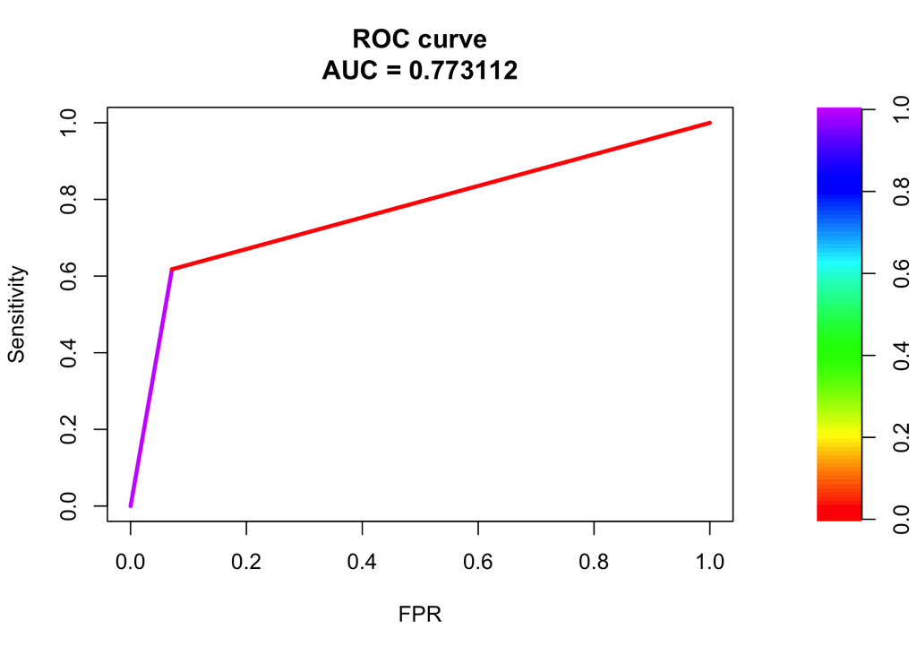

```r
PRROC_obj <- roc.curve(scores.class0 = predicted_classes, weights.class0=test_y, curve=TRUE)
plot(PRROC_obj)
```

*Plot ROC curve figure 2*

```r
roc = roc(test_y, predicted_classes)
```

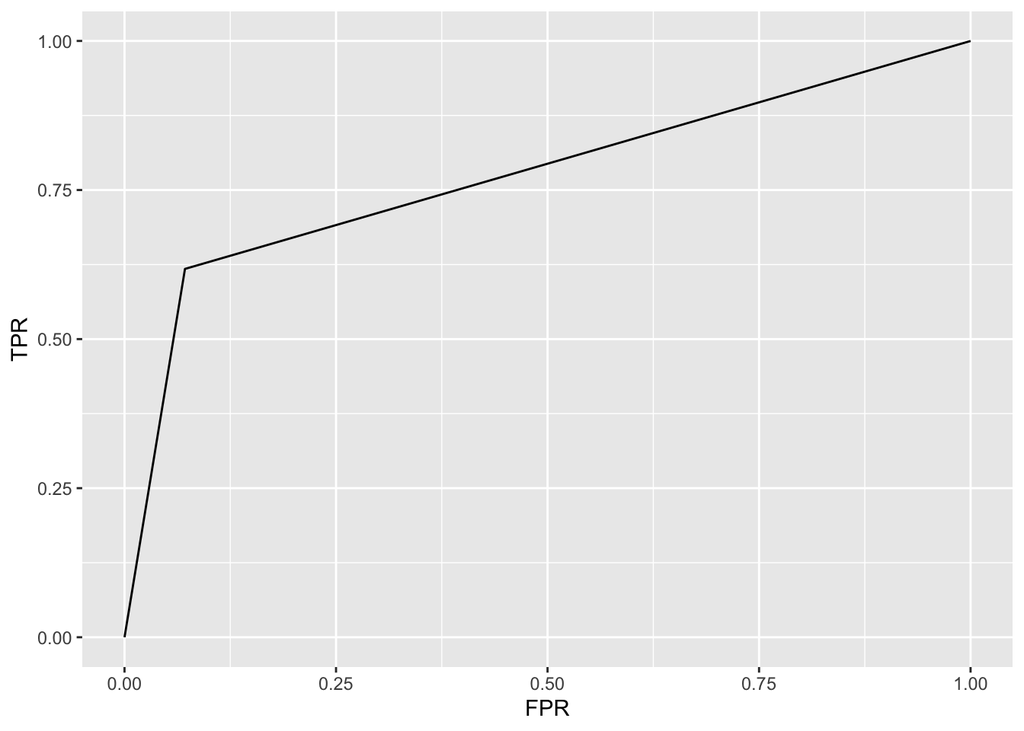

```r
roc_dat = data.frame(TPR=roc$sensitivities, FPR=1-roc$specificities)
ggplot(roc_dat, aes(x=FPR, y=TPR))+geom_line()
```

### Linear Regression with Lasso and Cross Validation

*Train Test split by 80% training and 20% testing datasets*

```r
X = model.matrix(age~0+.-age_group, data=df)
X = scale(X)
y= df$age

train_index = sample(1:nrow(df), 0.8 * nrow(df))

train_X = X[train_index, ]
train_y = y[train_index]

test_X = X[-train_index, ]
test_y = y[-train_index]
```

*10 fold cross validation and finding best lambda for ‘age’ numeric variable*

```r
set.seed(123)
cv_model = cv.glmnet(x=train_X, y=train_y, alpha=1, nfolds = 10)

best_lambda <- cv_model$lambda.1se
best_lambda
```

```
## [1] 0.09658004
```

*Plot cross validation model*

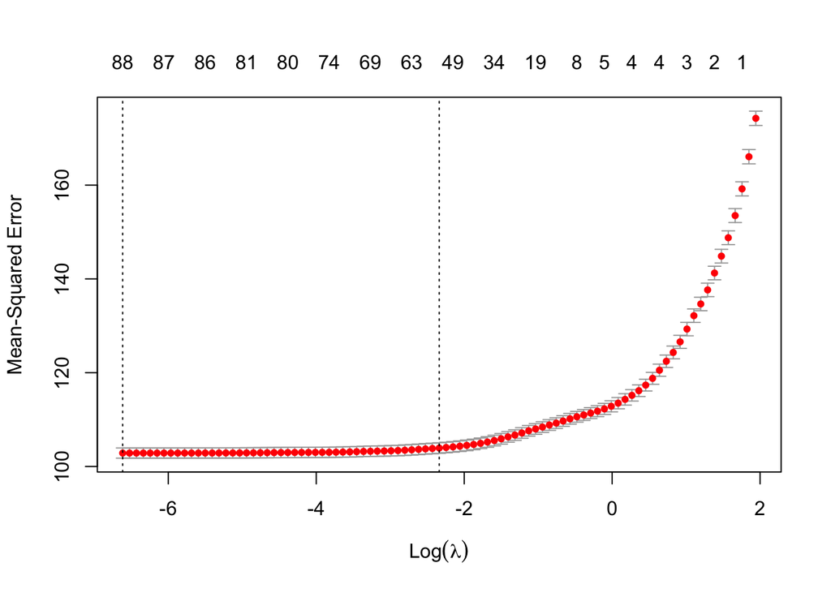

```r
plot(cv_model)
```

*Store names of predictor variables*

```r
coefficient_matrix = as.matrix(coef(cv_model))
non_zero_indices <- which(coefficient_matrix != 0)


non_zero_coefs <- coefficient_matrix[non_zero_indices, ]


names_of_predictors = rownames(coefficient_matrix)[non_zero_indices]
names_of_predictors
```

```
##  [1] "(Intercept)"                         "workclassFederal-gov"
##  [3] "workclassPrivate"                    "workclassSelf-emp-inc"
##  [5] "workclassSelf-emp-not-inc"           "workclassState-gov"
##  [7] "workclassWithout-pay"                "fnlwgt"
##  [9] "educationHighschool"                 "educationAssociates"
## [11] "educationSome-college"               "educationProf-school"
## [13] "educationMasters"                    "educationDoctorate"
## [15] "education.num"                       "marital.statusMarried-AF-spouse"
## [17] "marital.statusMarried-spouse-absent" "marital.statusNever-married"
## [19] "marital.statusSeparated"             "marital.statusWidowed"
## [21] "occupationArmed-Forces"              "occupationCraft-repair"
## [23] "occupationExec-managerial"           "occupationFarming-fishing"
## [25] "occupationHandlers-cleaners"         "occupationMachine-op-inspct"
## [27] "occupationOther-service"             "occupationPriv-house-serv"
## [29] "occupationProtective-serv"           "occupationTech-support"
## [31] "occupationTransport-moving"          "relationshipNot-in-family"
## [33] "relationshipOther-relative"          "relationshipOwn-child"
## [35] "relationshipWife"                    "raceBlack"
## [37] "raceOther"                           "capital.gain"
## [39] "capital.loss"                        "hours.per.week"
## [41] "native.countryCanada"                "native.countryCuba"
## [43] "native.countryEl-Salvador"           "native.countryGreece"
## [45] "native.countryGuatemala"             "native.countryHong"
## [47] "native.countryHungary"               "native.countryIndia"
## [49] "native.countryItaly"                 "native.countryMexico"
## [51] "native.countryPhilippines"           "native.countryScotland"
## [53] "native.countryTaiwan"                "income>50K"
```

*Finalize linear model using the ideal lambda value*

```r
final_model <- glmnet(train_X, train_y, alpha = 1, lambda = best_lambda)
```

*Plot cut-off point of Lasso Regression*

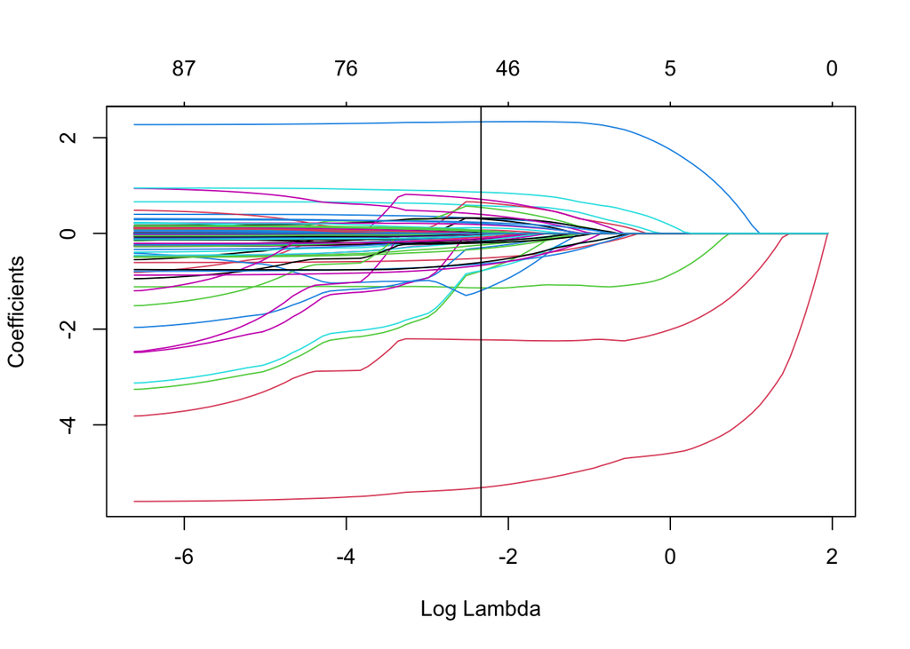

```
## integer(0)
```

```r
plot(glmnet(train_X, train_y, alpha = 1), xvar = "lambda")+abline(v=log(best_lambda))
```

*Predict ‘age’ using test set*

```r
predictions <- predict(final_model, newx = test_X, type = "response")
```

*RMSE, MAPE, R2*

```r
print(paste("Root Mean Squared Error:", round(RMSE(predictions, test_y), 3)))
```

```
## [1] "Root Mean Squared Error: 10.31"
```

```r
print(paste("Mean Absolute Error:", round(MAE(predictions, test_y), 3)))
```

```
## [1] "Mean Absolute Error: 8.101"
```

```r
print(paste("Mean Squared Error:", round(mean((predictions - test_y)^2), 3)))
```

```
## [1] "Mean Squared Error: 106.305"
```

```r
print(paste("Mean Absolute Percentage Error:", round(mean(abs((test_y-predictions)/test_y))*100,3)))
```

```
## [1] "Mean Absolute Percentage Error: 22.512"
```

```r
print(paste("R squared:", round(caret::R2(predictions, test_y),5)))
```

```
## [1] "R squared: 0.39747"
```

*PCA with categorical variables converted to factors*

```r
train_index = sample(1:nrow(df), 0.8 * nrow(df))

df2 <- df[,-c(17)]

train = df2[train_index,]
test = df2[train_index,]

pcr_model <- pcr(age~., data = train,scale = T)
summary(pcr_model)
```

```
## Data:    X dimension: 36177 89
##  Y dimension: 36177 1
## Fit method: svdpc
## Number of components considered: 89
## TRAINING: % variance explained
##      1 comps  2 comps  3 comps  4 comps  5 comps  6 comps  7 comps  8 comps
## X      4.181     7.17    9.989    12.15    14.09    15.99    17.70    19.37
## age   11.355    13.02   14.901    21.91    22.38    26.58    26.61    30.42
##      9 comps  10 comps  11 comps  12 comps  13 comps  14 comps  15 comps
## X      21.00     22.52     23.97     25.37     26.71     28.04     29.34
## age    30.49     30.56     30.58     30.95     31.07     31.17     31.78
##      16 comps  17 comps  18 comps  19 comps  20 comps  21 comps  22 comps
## X       30.63     31.91     33.18     34.43     35.67     36.90     38.10
## age     31.83     31.85     31.96     31.98     32.09     32.15     32.19
##      23 comps  24 comps  25 comps  26 comps  27 comps  28 comps  29 comps
## X       39.30     40.50     41.67     42.84     44.00     45.16     46.31
## age     32.22     32.26     32.44     33.83     33.84     34.06     34.06
##      30 comps  31 comps  32 comps  33 comps  34 comps  35 comps  36 comps
## X       47.46     48.59     49.73     50.86     51.99     53.12     54.24
## age     34.12     34.14     34.36     34.37     34.38     34.44     34.44
##      37 comps  38 comps  39 comps  40 comps  41 comps  42 comps  43 comps
## X       55.37     56.50     57.62     58.75     59.87     61.00     62.12
## age     34.45     34.45     34.46     34.46     34.46     34.46     34.46
##      44 comps  45 comps  46 comps  47 comps  48 comps  49 comps  50 comps
## X       63.25     64.37     65.50     66.62     67.74     68.87     69.99
## age     34.46     34.47     34.48     34.48     34.48     34.53     34.55
##      51 comps  52 comps  53 comps  54 comps  55 comps  56 comps  57 comps
## X       71.11     72.22     73.34     74.46     75.57     76.67     77.78
## age     34.56     34.63     34.64     34.68     34.68     34.80     35.21
##      58 comps  59 comps  60 comps  61 comps  62 comps  63 comps  64 comps
## X       78.87     79.96     81.05     82.14     83.22     84.29     85.35
## age     35.25     35.26     35.27     35.34     35.39     35.74     35.75
##      65 comps  66 comps  67 comps  68 comps  69 comps  70 comps  71 comps
## X       86.39     87.43     88.45     89.46     90.47     91.46     92.40
## age     35.80     35.85     35.86     35.90     36.19     36.19     37.39
##      72 comps  73 comps  74 comps  75 comps  76 comps  77 comps  78 comps
## X       93.33     94.21     95.07     95.87     96.63     97.37     97.97
## age     37.47     37.59     37.78     37.92     37.92     38.49     38.50
##      79 comps  80 comps  81 comps  82 comps  83 comps  84 comps  85 comps
## X       98.54     98.95     99.25     99.49     99.72     99.86     99.93
## age     38.56     39.17     39.17     39.57     40.81     40.95     40.95
##      86 comps  87 comps  88 comps  89 comps
## X       99.98     99.99    100.00    100.00
## age     40.98     41.17     41.28     41.28
```

*RMSE*

```r
predictions <- predict(pcr_model, newdata = train, ncomp = 75)
rmse <- sqrt(mean((test$age - predictions)^2))
rmse
```

```
## [1] 10.40209
```